# cleaned_Untitled6_(2) (1) (1)

Name:- Om Dipak Patil

Course:- MSc Data Science, AI and Digital Business

Module:- M508C Big Data Analytics

**AI-Powered Fake News Detector – Highlights the technology powering it**

**Introduction:**

The quick development of social media and digital media has significantly accelerated the dissemination of information, making it more challenging to seprate accurate news from inaccurate or deceptive content. In addition to mileading the public, fake news seriously jeopardizes social, political and economical stability. Conventional news verification techniques are frequently labor- intensive, manual, and inadequate to manage the huge number of daily news pieces. Therefore, intelligent system that can use cutting-edge computational approches to automaticlly and effectively identify fake news are desperately needed.

This project ensure the Natural-Language-Processing (NLP)the fake news detection platform. The system analyzes textual patterns, semantic context, and linguistic signals to differemiate between authentic and fradulant news stories by combinig methods like TF-IDF, word embeddings(Word2Vec/Glove), recurrent neural network(LSTM), and transformer based models (BERT). Accuracy and dependability are guranted by through exploratory data analysis (EDA), sophisticated preprocessing and stringent model evaluation, which makes this approch extremely useful for real world implementation in news verification system.

**Business problem:**

Fake News spread quickly in today's digital age, deceiving audiences, harming image, and influencing important choices in public health, politics, and economic. The vast amount of information makes it difficult for organizations and platform to manually check the legitmacy of material. An automated, intelligent system that can consistently identify and flag fake news is desperately neede to gurantee that users and those making choices have access to reliable and accurate information

**Problem statement:**

Public safety, informed decision-making, and societal trust are all seriously thrented by the pervasive spread of false information on digital platform. Current manual verification techniques are ineffective and cannot keep up with speed and amount of online content. The task is to create an automated, precise, and scalable system taht uses cutting-edge Natural Language Processting (NLP) and Machine Learning Technologies to analyze content, identify false ormisleading information, and distinguish it from authentic news in real-time

**Datset link:-**(https://www.kaggle.com/datasets/saurabhshahane/fake-news-classification

**Objectives:**

1. Using cutting-edge Artificial intelligence (AI) and Machine Learning techniques, create a robotic fake news detection system that can reliably identify news article as authentic or fradulent.
2. To identify Patterns, sementic context, and writing style distinctions between fake and authentic news, conduct through text analysis and feature engineering.
3. To optimize classification performance, use cutting edge models like Transformers-based models (BERT), TF-IDF with logistic regression and LSTM Network.
4. To guarantee dependability and equity, do through examination and validation utilizing a variety of measures as accuracy, precision, recall, f1 score, ROC-AUC, and Confusion matrix

**PHASE 1 — DATA ACQUISITION**

The quality, quantity, and variety of the news data gathered directly affect the model's dependability and performance, making data collecting an essential first stage in the false news detection process. By using sizable and relastic datset, the system is gauranteed to learn authentic linguistic patterns of both fake and real news, improving the final model's accuracy, objecivity, and suitability for pratical application.

```python
!pip install spacy
!python -m spacy download en_core_web_sm
!pip install nltk
!pip install transformers
```

[output not shown]

The foundation of the fake news detection system is made up of those libraries. Effective data processing, numerical calculation, and perceptive visualization are made possible by fundamental libraries like NumPy, Pandas, Matplotlab, and seaborn. Understanding news writing patterns requires advanced text preprocessing, linguistic analysis, sentiment recognition, and readability assessment, all of which are supported by NLP-focused tools like NLTK, spCy, TextBlob, and textstat. Libraries for feature engineering, such as Word2vec, n-gram, TF-IDF, assist in converting unstructured text into useful numerical representation. Classiacal, sequential, and tranformer-based model can be implementing using machine learning and deep learning framework (Scikit-learn, tenserflow, and Transformers). While evaluation and visualization libraries guarantee accurate model assessment, other tools like Levenshtein distance improve identification of altered or nearly identical information

```python
# BASIC LIBRARIES
import numpy as np
import pandas as pd
import matplotlib.pyplot as plt
import seaborn as sns

# TEXT PROCESSING
import re
import string
import nltk
from nltk.corpus import stopwords
from nltk.stem import WordNetLemmatizer
from nltk.stem import PorterStemmer
from nltk.tokenize import word_tokenize, sent_tokenize
# POS & NER (spaCy)
import spacy
# LANGUAGE DETECTION
!pip install langdetect
from langdetect import detect
# SENTIMENT ANALYSIS
from textblob import TextBlob
# READABILITY SCORES
!pip install textstat
import textstat
# FEATURE ENGINEERING: TF-IDF & N-GRAMS
from sklearn.feature_extraction.text import CountVectorizer, TfidfVectorizer
# WORD2VEC (FOR LSTM)
!pip install gensim
from gensim.models import Word2Vec, KeyedVectors
# TRAIN / TEST SPLIT & IMPBALANCED HANDLING
from sklearn.model_selection import train_test_split
from sklearn.utils.class_weight import compute_class_weight
# SMOTE for imbalance
from imblearn.over_sampling import SMOTE
# MACHINE LEARNING MODELS
from sklearn.linear_model import LogisticRegression
from sklearn.svm import SVC
# LSTM (DEEP LEARNING)
from tensorflow.keras.models import Sequential
from tensorflow.keras.layers import Dense, Embedding, LSTM, Dropout
from tensorflow.keras.preprocessing.text import Tokenizer
from tensorflow.keras.preprocessing.sequence import pad_sequences
# TRANSFORMER MODELS (BERT, DISTILBERT)
from transformers import BertTokenizer, TFBertForSequenceClassification
from transformers import DistilBertTokenizer, TFDistilBertForSequenceClassification
from transformers import AdamWeightDecay
# LEVENSHTEIN DISTANCE (Edit distance V1 & V2)
!pip install python-Levenshtein
import Levenshtein
# MODEL EVALUATION
from sklearn.metrics import (
    accuracy_score,
    precision_score,
    recall_score,
    f1_score,
    roc_auc_score,
    confusion_matrix,
    classification_report,
    precision_recall_fscore_support
)
# VISUALIZATION (WORD CLOUD)
from wordcloud import WordCloud
# WARNINGS
import warnings
warnings.filterwarnings("ignore")

print("All libraries imported successfully!")
```

[output not shown]

Load a datset into pandas dataFrame, print the entire dataset, and shows a little sample of first five rows.

```python
# Load dataset (CSV file)
df = pd.read_csv("/content/drive/MyDrive/Colab Notebooks/om_Nlp/WELFake_Dataset.csv")
print(df)
# Show first 5 rows
df.head()
```

```
       Unnamed: 0                                              title  \
0               0  LAW ENFORCEMENT ON HIGH ALERT Following Threat...
1               1                                                NaN
2               2  UNBELIEVABLE! OBAMA’S ATTORNEY GENERAL SAYS MO...
3               3  Bobby Jindal, raised Hindu, uses story of Chri...
4               4  SATAN 2: Russia unvelis an image of its terrif...
...           ...                                                ...
72129       72129  Russians steal research on Trump in hack of U....
72130       72130   WATCH: Giuliani Demands That Democrats Apolog...
72131       72131  Migrants Refuse To Leave Train At Refugee Camp...
72132       72132  Trump tussle gives unpopular Mexican leader mu...
72133       72133  Goldman Sachs Endorses Hillary Clinton For Pre...

                                                    text  label
0      No comment is expected from Barack Obama Membe...      1
1         Did they post their votes for Hillary already?      1
2       Now, most of the demonstrators gathered last ...      1
3      A dozen politically active pastors came here f...      0
4      The RS-28 Sarmat missile, dubbed Satan 2, will...      1
...                                                  ...    ...
72129  WASHINGTON (Reuters) - Hackers believed to be ...      0
72130  You know, because in fantasyland Republicans n...      1
72131  Migrants Refuse To Leave Train At Refugee Camp...      0
72132  MEXICO CITY (Reuters) - Donald Trump’s combati...      0
72133  Goldman Sachs Endorses Hillary Clinton For Pre...      1

[72134 rows x 4 columns]
```

|  | Unnamed: 0 | title | text | label |
| --- | --- | --- | --- | --- |
| 0 | 0 | LAW ENFORCEMENT ON HIGH ALERT Following Threat... | No comment is expected from Barack Obama Membe... | 1 |
| 1 | 1 | NaN | Did they post their votes for Hillary already? | 1 |
| 2 | 2 | UNBELIEVABLE! OBAMA’S ATTORNEY GENERAL SAYS MO... | Now, most of the demonstrators gathered last ... | 1 |
| 3 | 3 | Bobby Jindal, raised Hindu, uses story of Chri... | A dozen politically active pastors came here f... | 0 |
| 4 | 4 | SATAN 2: Russia unvelis an image of its terrif... | The RS-28 Sarmat missile, dubbed Satan 2, will... | 1 |

This function shows a synopis of the datset that includes memnory use, non-null counts, column names, data types.

```python
print("Dataset information:")
df.info()
```

```
Dataset information:
<class 'pandas.core.frame.DataFrame'>
RangeIndex: 72134 entries, 0 to 72133
Data columns (total 4 columns):
 #   Column      Non-Null Count  Dtype
---  ------      --------------  -----
 0   Unnamed: 0  72134 non-null  int64
 1   title       71576 non-null  object
 2   text        72095 non-null  object
 3   label       72134 non-null  int64
dtypes: int64(2), object(2)
memory usage: 2.2+ MB
```

This function produces statistics with descriptions, such as count, mean, standard deviation, the lowest, highest, and quartiles, for the numerical column in dataset.

```python
df.describe()
```

|  | Unnamed: 0 | label |
| --- | --- | --- |
| count | 72134.000000 | 72134.000000 |
| mean | 36066.500000 | 0.514404 |
| std | 20823.436496 | 0.499796 |
| min | 0.000000 | 0.000000 |
| 25% | 18033.250000 | 0.000000 |
| 50% | 36066.500000 | 1.000000 |
| 75% | 54099.750000 | 1.000000 |
| max | 72133.000000 | 1.000000 |

**PHASE 2 — TEXT CLEANING**

```python
duplicates_count = df.duplicated().sum()
print("Total Duplicate Rows:", duplicates_count)
```

```
Total Duplicate Rows: 0
```

Display Class Distribution

```python
df['label'].value_counts()
(df['label'].value_counts(normalize=True) * 100).round(2)
```

| label | proportion |
| --- | --- |
| 1 | 51.44 |
| 0 | 48.56 |

**dtype:** float64

Class Distribution:- This function makes count plot to show the class labels (Fake vs Real) are disributed. Since the datset is already balanced, resampling methods like SMOTE are not necesary, as the image illustartes.

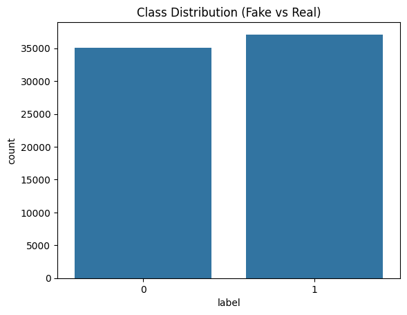

```python
sns.countplot(data=df, x='label')
plt.title("Class Distribution (Fake vs Real)")
plt.show()
```

```python
import nltk
from nltk.tokenize import word_tokenize
from nltk.corpus import stopwords

nltk.download('punkt')
nltk.download('stopwords')
nltk.download('punkt_tab')
```

```
True
```

**Text cleaning function:**

Im order to prepare raw text data from NLP tasks, the code defines a simple text preprocessing function. After making sure that the submission is a proper string, it uses BeautifulSoup to remove HTML tags, remove URL, and users regular expressions to remove emojis. After that, it eliminates unneeded speical character while keeping letetrs, numbers, and standarpunctuation. Lastly, it normalizes whitespace by eliminating superflous spaces. The end product is a clear, consistent text that can be used for additional modeling or analysis.

```python
from bs4 import BeautifulSoup

def basic_clean(text):
    if not isinstance(text, str):
        return ""

    # 1. Remove HTML tags
    text = BeautifulSoup(text, "html.parser").get_text()

    # 2. Remove URLs
    text = re.sub(r'http\S+|www\S+|https\S+', '', text)

    # 3. Remove Emojis
    emoji_pattern = re.compile(
        "["
        u"\U0001F600-\U0001F64F"
        u"\U0001F300-\U0001F5FF"
        u"\U0001F680-\U0001F6FF"
        u"\U0001F1E0-\U0001F1FF"
        "]+",
        flags=re.UNICODE
    )
    text = emoji_pattern.sub(r'', text)

    # 4. Remove special characters (keep letters, numbers, punctuation)
    text = re.sub(r"[^a-zA-Z0-9\s.,!?]", " ", text)

    # 5. Remove extra spaces
    text = re.sub(r"\s+", " ", text).strip()

    return text
```

```python
def tokenize_text(text):
    tokens = word_tokenize(text)
    return tokens
```

```python
stop_words = set(stopwords.words("english"))
def remove_stopwords(tokens):
    return [word for word in tokens if word.lower() not in stop_words]
```

```python
def preprocess_text(text):
    cleaned = basic_clean(text)
    tokens = tokenize_text(cleaned)
    tokens = remove_stopwords(tokens)
    return tokens
```

```python
df["cleaned_text"] = df["text"].apply(basic_clean)
df["tokens"] = df["cleaned_text"].apply(tokenize_text)
df["tokens_no_stopwords"] = df["tokens"].apply(remove_stopwords)

df.head()
```

|  | Unnamed: 0 | title | text | label | cleaned_text | tokens | tokens_no_stopwords |
| --- | --- | --- | --- | --- | --- | --- | --- |
| 0 | 0 | LAW ENFORCEMENT ON HIGH ALERT Following Threat... | No comment is expected from Barack Obama Membe... | 1 | No comment is expected from Barack Obama Membe... | [No, comment, is, expected, from, Barack, Obam... | [comment, expected, Barack, Obama, Members, FY... |
| 1 | 1 | NaN | Did they post their votes for Hillary already? | 1 | Did they post their votes for Hillary already? | [Did, they, post, their, votes, for, Hillary, ... | [post, votes, Hillary, already, ?] |
| 2 | 2 | UNBELIEVABLE! OBAMA’S ATTORNEY GENERAL SAYS MO... | Now, most of the demonstrators gathered last ... | 1 | Now, most of the demonstrators gathered last n... | [Now, ,, most, of, the, demonstrators, gathere... | [,, demonstrators, gathered, last, night, exer... |
| 3 | 3 | Bobby Jindal, raised Hindu, uses story of Chri... | A dozen politically active pastors came here f... | 0 | A dozen politically active pastors came here f... | [A, dozen, politically, active, pastors, came,... | [dozen, politically, active, pastors, came, pr... |
| 4 | 4 | SATAN 2: Russia unvelis an image of its terrif... | The RS-28 Sarmat missile, dubbed Satan 2, will... | 1 | The RS 28 Sarmat missile, dubbed Satan 2, will... | [The, RS, 28, Sarmat, missile, ,, dubbed, Sata... | [RS, 28, Sarmat, missile, ,, dubbed, Satan, 2,... |

**PHASE 3 — EXPLORATORY DATA ANALYSIS (EDA)**

```python
import spacy
nlp = spacy.load("en_core_web_sm", disable=["ner", "parser"])
```

This defines a function taht extracts basic textual prioperties, such as word count, character count, sentene count, and average word length, using spaCy and return the results as pandas series for additional analysis or modeling.

```python
def extract_features_spacy(text):
    if not isinstance(text, str):
        return pd.Series([0, 0, 0, 0])

    doc = nlp(text)

    words = [token.text for token in doc]
    word_count = len(words)
    char_count = len(text)

    # sentence count using spaCy's sentencizer (auto)
    try:
        sentence_count = len(list(doc.sents))
    except:
        sentence_count = 1

    # average word length
    if word_count > 0:
        avg_word_length = np.mean([len(w) for w in words])
    else:
        avg_word_length = 0

    return pd.Series([word_count, char_count, sentence_count, avg_word_length])
```

```python
df_sample = df.sample(n=5000, random_state=42)
```

Word count, character count, sentence count, and average word length are calculated by applying the feature extraction function to the cleaned text. The extracted features are then previewed with cleaned text in first few rows.

```python
df_sample[['word_count','char_count','sentence_count','avg_word_length']] = \
    df_sample['cleaned_text'].apply(extract_features_spacy)
```

```python
df_sample[['cleaned_text',
           'word_count',
           'char_count',
           'sentence_count',
           'avg_word_length']].head()
```

|  | cleaned_text | word_count | char_count | sentence_count | avg_word_length |
| --- | --- | --- | --- | --- | --- |
| 61370 |  | 0.0 | 0.0 | 0.0 | 0.000000 |
| 2189 | And now a message of peace and unity from one ... | 173.0 | 800.0 | 1.0 | 3.716763 |
| 60609 | WINNIPEG, Manitoba Reuters Former U.S. Preside... | 487.0 | 2599.0 | 1.0 | 4.433265 |
| 51565 | The two Franciscan friars, complete with robes... | 1057.0 | 5157.0 | 1.0 | 4.000946 |
| 39431 | Approximately 1 in 68 children has an autism s... | 38.0 | 197.0 | 1.0 | 4.289474 |

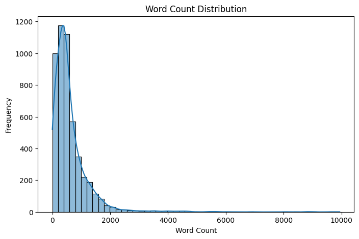

```python
plt.figure(figsize=(8,5))
sns.histplot(df_sample['word_count'], bins=50, kde=True)
plt.title("Word Count Distribution")
plt.xlabel("Word Count")
plt.ylabel("Frequency")
plt.show()
```

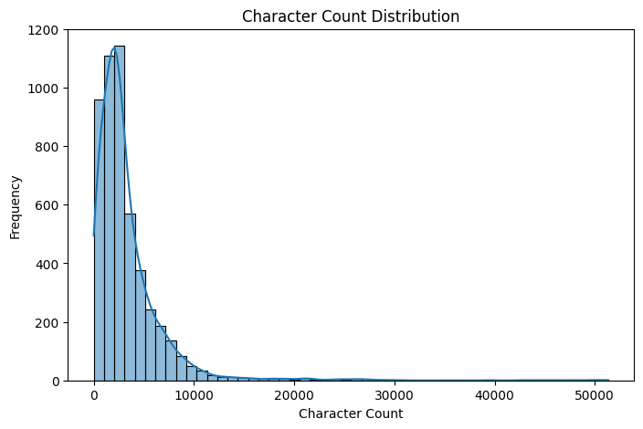

```python
plt.figure(figsize=(8,5))
sns.histplot(df_sample['char_count'], bins=50, kde=True)
plt.title("Character Count Distribution")
plt.xlabel("Character Count")
plt.ylabel("Frequency")
plt.show()
```

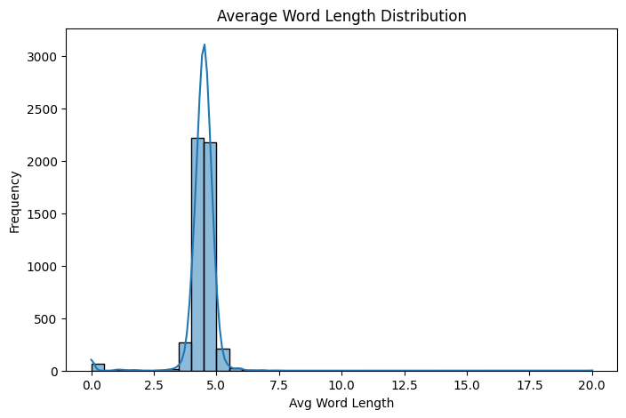

```python
plt.figure(figsize=(8,5))
sns.histplot(df_sample['avg_word_length'], bins=40, kde=True)
plt.title("Average Word Length Distribution")
plt.xlabel("Avg Word Length")
plt.ylabel("Frequency")
plt.show()
```

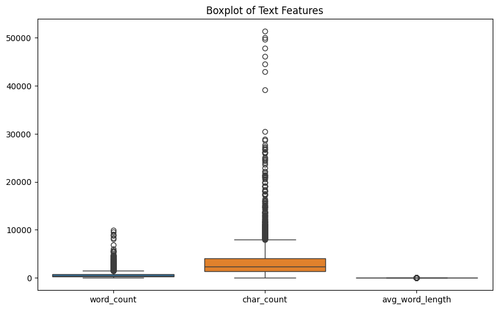

```python
plt.figure(figsize=(10,6))
sns.boxplot(data=df_sample[['word_count','char_count','avg_word_length']])
plt.title("Boxplot of Text Features")
plt.show()
```

**Feature Extraction Dashboard:**

This graphic displays an extensive dashboard that compares the word count, character count, sentence count, and average word length of authentic and fraudulent news stories. The plots provide a clear visual comparison by highlighting the distribution of these attributs in both classes using superimposed histogram with density normiloazation. The simple layout and color -coded design-pink for false news and blue for true news- help highlight minute variation in writing style and design, which can be useful markers for feature based modeline and fake identiification .

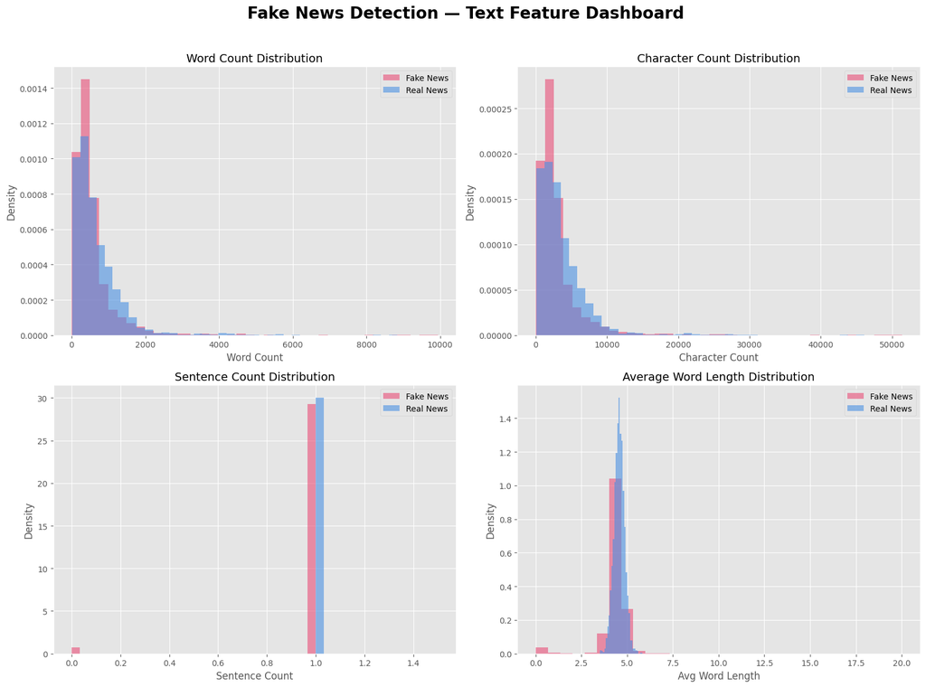

```python
colors = {0: "#4A90E2", 1: "#E94E77"}     # Blue = Real, Pink = Fake
labels = {0: "Real News", 1: "Fake News"}
plt.style.use('ggplot')  # clean dashboard aesthetic

# Create Dashboard Figure
fig, axes = plt.subplots(2, 2, figsize=(16, 12))
fig.suptitle(" Fake News Detection — Text Feature Dashboard", fontsize=20, fontweight='bold')

# Word Count Distribution

ax = axes[0, 0]
for lbl in df_sample['label'].unique():
    subset = df_sample[df_sample['label'] == lbl]['word_count']
    ax.hist(subset, bins=40, alpha=0.6, color=colors[lbl], label=labels[lbl], density=True)

ax.set_title("Word Count Distribution", fontsize=14)
ax.set_xlabel("Word Count")
ax.set_ylabel("Density")
ax.legend()

#  Character Count Distribution
ax = axes[0, 1]
for lbl in df_sample['label'].unique():
    subset = df_sample[df_sample['label'] == lbl]['char_count']
    ax.hist(subset, bins=40, alpha=0.6, color=colors[lbl], label=labels[lbl], density=True)

ax.set_title("Character Count Distribution", fontsize=14)
ax.set_xlabel("Character Count")
ax.set_ylabel("Density")
ax.legend()
# Sentence Count Distribution
ax = axes[1, 0]
for lbl in df_sample['label'].unique():
    subset = df_sample[df_sample['label'] == lbl]['sentence_count']
    ax.hist(subset, bins=30, alpha=0.6, color=colors[lbl], label=labels[lbl], density=True)

ax.set_title("Sentence Count Distribution", fontsize=14)
ax.set_xlabel("Sentence Count")
ax.set_ylabel("Density")
ax.legend()

#  Average Word Length
ax = axes[1, 1]
for lbl in df_sample['label'].unique():
    subset = df_sample[df_sample['label'] == lbl]['avg_word_length']
    ax.hist(subset, bins=30, alpha=0.6, color=colors[lbl], label=labels[lbl], density=True)

ax.set_title("Average Word Length Distribution", fontsize=14)
ax.set_xlabel("Avg Word Length")
ax.set_ylabel("Density")
ax.legend()

# Layout formatting
plt.tight_layout(rect=[0, 0, 1, 0.96])
plt.show()
```

**WordCloud Visualization — Fake vs Real News:**

Using Cleaned text data, this code creates and display word cloud bor actual and fradulent news stories. The word cloud provide an accessible comaprison of common themens and linguisitc patterns utilized in fake versus real vs fake news by collecting all content within each class and highlighting the most frequently occuring phrases. The side-by-side dashborad design makes it simple to visully analyze how the classes language and emphasis differ.

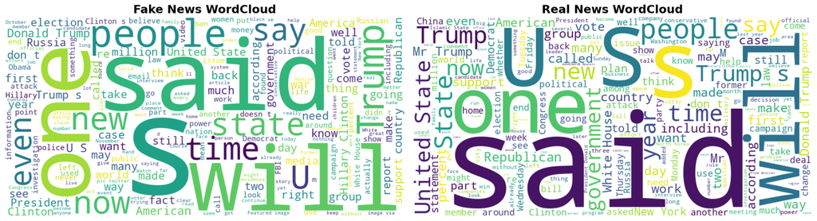

```python
!pip install wordcloud
from wordcloud import WordCloud
# Generate combined text for each class
fake_text = " ".join(df_sample[df_sample['label'] == 1]['cleaned_text'])
real_text = " ".join(df_sample[df_sample['label'] == 0]['cleaned_text'])
# Create word clouds
wc_fake = WordCloud(width=800, height=400, background_color='white', max_words=200).generate(fake_text)
wc_real = WordCloud(width=800, height=400, background_color='white', max_words=200).generate(real_text)
# Dashboard-style layout
plt.figure(figsize=(18, 8))
# Fake News WordCloud (Left)
plt.subplot(1, 2, 1)
plt.imshow(wc_fake, interpolation='bilinear')
plt.title("Fake News WordCloud", fontsize=18, fontweight='bold')
plt.axis('off')
# Real News WordCloud (Right)
plt.subplot(1, 2, 2)
plt.imshow(wc_real, interpolation='bilinear')
plt.title("Real News WordCloud", fontsize=18, fontweight='bold')
plt.axis('off')
plt.tight_layout()
plt.show()
```

**Treemap of Top Fake News Keywords**

The Top 20 most common terms in fake news stories are visulaized using treemap created by this code. Pripor to counting the frequency of each token, it cleans and tokenizes the text, eliminating common stopword and short words. The treemap offers an easy to understand visual breakdown of important terms frequently found in false news material, with each keyword displayed proportionately to its icidence.

```
Downloading squarify-0.4.4-py3-none-any.whl (4.1 kB)
```

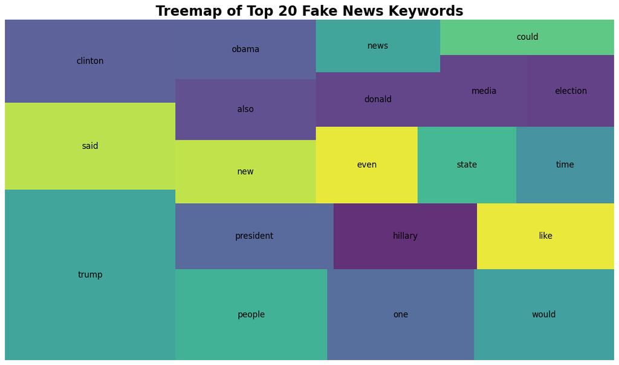

```python
!pip install squarify
import squarify
from collections import Counter
from nltk.corpus import stopwords
# Ensure stopwords downloaded
nltk.download('stopwords')
stop_words = set(stopwords.words('english'))
# Function to get clean tokens
def get_tokens(text):
    tokens = re.findall(r'\b\w+\b', text.lower())
    tokens = [t for t in tokens if t not in stop_words and len(t) > 2]
    return tokens
# Extract fake news text only
fake_texts = df_sample[df_sample['label'] == 1]['cleaned_text'].astype(str)
# Flatten tokens
all_fake_tokens = []
for txt in fake_texts:
    all_fake_tokens.extend(get_tokens(txt))
# Count frequencies
fake_word_freq = Counter(all_fake_tokens).most_common(20)
# Prepare data for treemap
words = [w for w, c in fake_word_freq]
counts = [c for w, c in fake_word_freq]
# Treemap visualization
plt.figure(figsize=(16, 9))
squarify.plot(sizes=counts, label=words, alpha=0.85, text_kwargs={'fontsize': 12})
plt.title("Treemap of Top 20 Fake News Keywords", fontsize=20, fontweight='bold')
plt.axis('off')
plt.show()
```

**POS Tag Distribution — Fake vs Real News**

The distribution of Part of Speech (POS) tags in both authentic and false news stories is shown by this code. It allows for direct comparisioon of linguistic patterns by counting the instances of each POS tag in both groups and producing a side by side bar chart. For text analysis and feature engineering in the identification of fake news the plot aids in identifying varitions in syntax and writing style between fake and authentic news content.

```python
import spacy
nlp = spacy.load("en_core_web_sm")
from collections import Counter

def get_pos_tags(text):
    doc = nlp(text)
    return [token.pos_ for token in doc]
```

```python
fake_sample = df_sample[df_sample['label'] == 1].head(1000)
real_sample = df_sample[df_sample['label'] == 0].head(1000)

fake_pos = []
real_pos = []

for t in fake_sample['cleaned_text']:
    fake_pos.extend(get_pos_tags(t))

for t in real_sample['cleaned_text']:
    real_pos.extend(get_pos_tags(t))
```

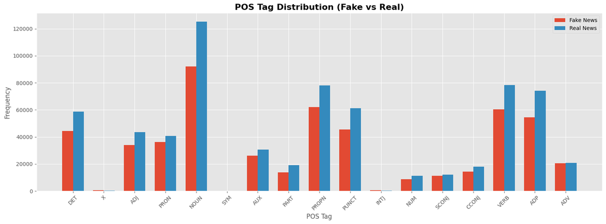

```python
fake_pos_count = Counter(fake_pos)
real_pos_count = Counter(real_pos)
labels = list(set(list(fake_pos_count.keys()) + list(real_pos_count.keys())))
fake_vals = [fake_pos_count.get(l, 0) for l in labels]
real_vals = [real_pos_count.get(l, 0) for l in labels]

x = np.arange(len(labels))
width = 0.35

plt.figure(figsize=(16,6))
plt.bar(x - width/2, fake_vals, width, label='Fake News')
plt.bar(x + width/2, real_vals, width, label='Real News')

plt.xticks(x, labels, rotation=45)
plt.title("POS Tag Distribution (Fake vs Real)", fontsize=16, fontweight='bold')
plt.xlabel("POS Tag")
plt.ylabel("Frequency")
plt.legend()
plt.tight_layout()
plt.show()
```

**Named Entity Distribution — Fake vs Real News**

```python
def get_entities(text):
    doc = nlp(text)
    return [ent.label_ for ent in doc.ents]
```

```python
fake_entities = []
real_entities = []

for t in fake_sample['cleaned_text']:
    fake_entities.extend(get_entities(t))

for t in real_sample['cleaned_text']:
    real_entities.extend(get_entities(t))
```

```python
fake_ner_count = Counter(fake_entities)
real_ner_count = Counter(real_entities)
```

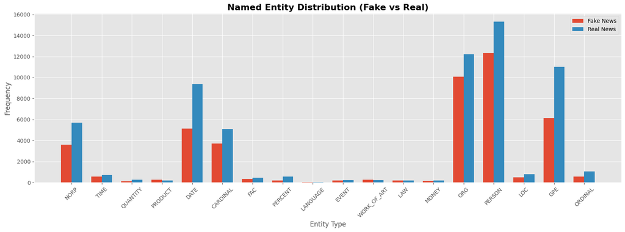

```python
labels = list(set(list(fake_ner_count.keys()) + list(real_ner_count.keys())))
fake_vals = [fake_ner_count.get(l, 0) for l in labels]
real_vals = [real_ner_count.get(l, 0) for l in labels]

x = np.arange(len(labels))
width = 0.35

plt.figure(figsize=(16,6))
plt.bar(x - width/2, fake_vals, width, label='Fake News')
plt.bar(x + width/2, real_vals, width, label='Real News')

plt.xticks(x, labels, rotation=45)
plt.title("Named Entity Distribution (Fake vs Real)", fontsize=16, fontweight='bold')
plt.xlabel("Entity Type")
plt.ylabel("Frequency")
plt.legend()
plt.tight_layout()
plt.show()
```

**PHASE 4 — ADVANCED NLP PREPROCESSING**

**1. Tokenization**

**BERT Tokenization:-** This code tokenizes text using the BERT tokenizer and the Hugging Face Transformer library. It converts cleaned text into BERT- compitable tokens by loading the pre-trained bert-base-uncased token maekr and applying it to datset. In order to prepare the data for BERT based NLP modeling, the generated dataframe shows either the initally cleaned text and its matching tokized representaion

```python
!pip install transformers
from transformers import BertTokenizer
bert_tokenizer = BertTokenizer.from_pretrained('bert-base-uncased')
```

```python
def bert_tokenize(text):
    return bert_tokenizer.tokenize(text)
df_sample_small = df_sample.head(2000)
df_sample_small['bert_tokens'] = df_sample_small['cleaned_text'].apply(bert_tokenize)
df_sample_small[['cleaned_text', 'bert_tokens']].head()
```

|  | cleaned_text | bert_tokens |
| --- | --- | --- |
| 61370 |  | [] |
| 2189 | And now a message of peace and unity from one ... | [and, now, a, message, of, peace, and, unity, ... |
| 60609 | WINNIPEG, Manitoba Reuters Former U.S. Preside... | [winnipeg, ,, manitoba, reuters, former, u, .,... |
| 51565 | The two Franciscan friars, complete with robes... | [the, two, franciscan, friars, ,, complete, wi... |
| 39431 | Approximately 1 in 68 children has an autism s... | [approximately, 1, in, 68, children, has, an, ... |

**SpaCy Tokenization:-** uses spaCy to tokenize the cleaned text, turning each text into a list of tokens. The resuklt is the then added as a new column for additional text analysis.

```python
def spacy_tokenize(text):
    doc = nlp(text)
    return [token.text for token in doc]
df_sample['spacy_tokens'] = df_sample['cleaned_text'].apply(spacy_tokenize)
df_sample[['cleaned_text', 'spacy_tokens']].head()
```

|  | cleaned_text | spacy_tokens |
| --- | --- | --- |
| 61370 |  | [] |
| 2189 | And now a message of peace and unity from one ... | [And, now, a, message, of, peace, and, unity, ... |
| 60609 | WINNIPEG, Manitoba Reuters Former U.S. Preside... | [WINNIPEG, ,, Manitoba, Reuters, Former, U.S.,... |
| 51565 | The two Franciscan friars, complete with robes... | [The, two, Franciscan, friars, ,, complete, wi... |
| 39431 | Approximately 1 in 68 children has an autism s... | [Approximately, 1, in, 68, children, has, an, ... |

**2. Stemming & Lemmatization**

```python
from nltk.stem import PorterStemmer, SnowballStemmer
porter = PorterStemmer()
snowball = SnowballStemmer("english")
nlp = spacy.load("en_core_web_sm")
```

**Porter Stemming**

The input text is tokenized using this function, which then applies the Porter Stemmer to each token. By reducing words to their root forms, stemming helps normalize word variance and shrinks vocabulary, both of which can enhance text cateorization model's effeciveness and performance.

```python
def porter_stem_text(text):
    tokens = nltk.word_tokenize(text)
    return [porter.stem(word) for word in tokens]
```

**Snowball Stemming**

This function applies the Snowball Stemmer to every word after tokenizing the enterd text. Snowball stemming helps enhance text normalization and feature quality for subsequent automatic language precessing tasx by reducing words to their most basic formns in more uniform and liguistic aware manner

```python
def snowball_stem_text(text):
    tokens = nltk.word_tokenize(text)
    return [snowball.stem(word) for word in tokens]
```

**spaCy Lemmatization**

Using spaCy, this function lemmatizes the input text by returning each word to its original dictionalry from while maintaining its meaning. By considering various word forms as the same, lemmatization reduces vocabulary size and enhances model comparision, making the text more appropriate for precise NLP analysis and modeling.

```python
def spacy_lemmatize(text):
    doc = nlp(text)
    return [token.lemma_ for token in doc]
# Apply on Sample Dataset
df_sample_small = df_sample.head(2000)
```

**Apply Porter Stemmer**

This line stores the stemmed tokens in new column named porter_stemmed afterb applying the porter stemming function to the cleaned text. By breaking down words into their most basic forms, it aids in word normalization, simplifies the text, and can increase the effectiveness of features extraction and machine learning models.

```python
df_sample_small['porter_stemmed'] = df_sample_small['cleaned_text'].apply(porter_stem_text)
```

**Apply Snowball Stemmer**

This code save the stemmed tokens in new column called snowball_stemmed after applying the snowball stemming algorithm to the cleaned text. It helps normalize word forms and improve model performance during text analysis by offering a more sophisticated and language- aware stemming technique.

```python
df_sample_small['snowball_stemmed'] = df_sample_small['cleaned_text'].apply(snowball_stem_text)
```

**Apply spaCy Lemmatizer**

Compares teh cleaned text with Porter and Snowball stemmed versions after lemmatization. The generated dataframe displays the various normalization procedures applied to each text, with stemming producing shortert, root forms and lemmatization mainitaing the complete word forms.

```python
df_sample_small['lemmatized'] = df_sample_small['cleaned_text'].apply(spacy_lemmatize)
```

```python
df_sample_small[['cleaned_text',
                 'porter_stemmed',
                 'snowball_stemmed',
                 'lemmatized']].head()
```

|  | cleaned_text | porter_stemmed | snowball_stemmed | lemmatized |
| --- | --- | --- | --- | --- |
| 61370 |  | [] | [] | [] |
| 2189 | And now a message of peace and unity from one ... | [and, now, a, messag, of, peac, and, uniti, fr... | [and, now, a, messag, of, peac, and, uniti, fr... | [and, now, a, message, of, peace, and, unity, ... |
| 60609 | WINNIPEG, Manitoba Reuters Former U.S. Preside... | [winnipeg, ,, manitoba, reuter, former, u.s., ... | [winnipeg, ,, manitoba, reuter, former, u.s., ... | [WINNIPEG, ,, Manitoba, Reuters, former, U.S.,... |
| 51565 | The two Franciscan friars, complete with robes... | [the, two, franciscan, friar, ,, complet, with... | [the, two, franciscan, friar, ,, complet, with... | [the, two, franciscan, friar, ,, complete, wit... |
| 39431 | Approximately 1 in 68 children has an autism s... | [approxim, 1, in, 68, children, ha, an, autism... | [approxim, 1, in, 68, children, has, an, autis... | [approximately, 1, in, 68, child, have, an, au... |

**3. POS Tagging**

This code use spaCy to extract POS tags from cleaned text. It transformers the count dictionaries into distinct feature column for every POS tag after storing the complete sequence of POS tag and their counts. The resultant dataframe ffers comprenhesive synthetics data that can be utilized as features in NLP models or for linguistic study

```python
def get_pos_tags(text):
    doc = nlp(text)
    return [token.pos_ for token in doc]
from collections import Counter

def get_pos_counts(text):
    doc = nlp(text)
    pos_tags = [token.pos_ for token in doc]
    return Counter(pos_tags)
# Apply on sample only
df_pos = df_sample.head(2000).copy()
```

```python
df_pos['pos_tags'] = df_pos['cleaned_text'].apply(get_pos_tags)
df_pos['pos_count'] = df_pos['cleaned_text'].apply(get_pos_counts)
# Convert dictionary column to separate feature columns
pos_df = df_pos['pos_count'].apply(pd.Series).fillna(0)
# Add prefix to avoid confusion
pos_df = pos_df.add_prefix("POS_")
# Merge back into dataframe
df_pos = pd.concat([df_pos, pos_df], axis=1)
df_pos[['cleaned_text', 'pos_tags', 'pos_count']].head()
```

|  | cleaned_text | pos_tags | pos_count |
| --- | --- | --- | --- |
| 61370 |  | [] | {} |
| 2189 | And now a message of peace and unity from one ... | [CCONJ, ADV, DET, NOUN, ADP, NOUN, CCONJ, NOUN... | {'CCONJ': 7, 'ADV': 8, 'DET': 21, 'NOUN': 21, ... |
| 60609 | WINNIPEG, Manitoba Reuters Former U.S. Preside... | [PROPN, PUNCT, PROPN, PROPN, ADJ, PROPN, PROPN... | {'PROPN': 61, 'PUNCT': 46, 'ADJ': 30, 'VERB': ... |
| 51565 | The two Franciscan friars, complete with robes... | [DET, NUM, ADJ, NOUN, PUNCT, ADJ, ADP, NOUN, P... | {'DET': 110, 'NUM': 21, 'ADJ': 52, 'NOUN': 190... |
| 39431 | Approximately 1 in 68 children has an autism s... | [ADV, NUM, ADP, NUM, NOUN, VERB, DET, NOUN, NO... | {'ADV': 4, 'NUM': 2, 'ADP': 2, 'NOUN': 8, 'VER... |

**4. Named Entity Recognition (NER)**

By using spaCy to extract named entites from cleaned text and classify them into specified classes (eg, PERSON, ORG, GPE, DATE). The generated dataframe allows for systematic analyisis of significant data in the text by storing each rext togeather with an index of discovered elements

```python
ENTITY_TYPES = [
    "PERSON",      # People names
    "ORG",         # Organizations
    "GPE",         # Countries, cities
    "LOC",         # Non-GPE locations
    "NORP",        # Political groups, religions, nationalities
    "EVENT",       # Elections, wars, attacks
    "PRODUCT",     # Weapons, gadgets
    "WORK_OF_ART", # Books, movies
    "LAW",         # Legal documents
    "DATE"         # Dates
]
def extract_named_entities(text):
    doc = nlp(text)

    # create dictionary with empty lists
    entities = {etype: [] for etype in ENTITY_TYPES}

    for ent in doc.ents:
        if ent.label_ in entities:
            entities[ent.label_].append(ent.text)

    return entities
df_ner_sample = df_sample.head(2000).copy()
df_ner_sample['entities'] = df_ner_sample['cleaned_text'].apply(extract_named_entities)
df_ner_sample[['cleaned_text', 'entities']].head(10)
```

|  | cleaned_text | entities |
| --- | --- | --- |
| 61370 |  | {'PERSON': [], 'ORG': [], 'GPE': [], 'LOC': []... |
| 2189 | And now a message of peace and unity from one ... | {'PERSON': ['Donald J. Trump', 'Donald Trump',... |
| 60609 | WINNIPEG, Manitoba Reuters Former U.S. Preside... | {'PERSON': ['Jimmy Carter', 'Carter', 'Carter'... |
| 51565 | The two Franciscan friars, complete with robes... | {'PERSON': ['Josiah Wise', 'Nicholas Spano', '... |
| 39431 | Approximately 1 in 68 children has an autism s... | {'PERSON': [], 'ORG': [], 'GPE': [], 'LOC': []... |
| 47839 | The CNN debate between Democratic candidates H... | {'PERSON': ['Hillary Clinton', 'Bernie Sanders... |
| 42729 | By Dady Chery and Gilbert MercierAll writers w... | {'PERSON': ['Gilbert MercierAll', 'Martin Luth... |
| 37882 | WASHINGTON Reuters U.S. Vice President elect M... | {'PERSON': ['Mike Pence', 'Fidel Castro', 'Cas... |
| 10893 | WASHINGTON Reuters U.S. President Donald Trump... | {'PERSON': ['Donald Trump', 'Barack Obama'], '... |
| 46977 | 0 comments The White house is refusing to deny... | {'PERSON': ['Obama', 'Donald Trump', 'Obama De... |

**PHASE 5 — FEATURE ENGINEERING**

**1. TF-IDF Features (Unigram, Bigram, Trigram)**

In order to transforms unstructured textual data into useful numerical representaions, this stage extract TF-IDF **(Term Frequency-Inverse Document Frequency)** features from cleaned text. To record single words, two-word phrases, and three word phrases, respectively, unigrams, bigrams, and trigrams are created. The model is guranteed to concentarte on most meaningful terms while maintaining computational efficiency by using capped feature size of 5,000. Each n-gram representation's dimensionality is verified by printing the featue matrix shapes.

Additionally it possible to see which words and phrase the TF-IDF model is emphasizing by looking at extracted feature names for Unigrams, bigrams, and trigrams. In addition to revealing significant patterns like commonly recuring terms and contextual word pairings, this gives the text data interpretability. In the detection of fake news, these TF-IDF feature provide a solid foundation for conventional machine learning models susch as LOgistic regression.

```python
from sklearn.feature_extraction.text import TfidfVectorizer
# Use 2000-sample for speed
df_tfidf = df_sample.head(2000).copy()
texts = df_tfidf['cleaned_text'].astype(str).tolist()
tfidf_uni = TfidfVectorizer(ngram_range=(1,1), max_features=5000)
X_uni = tfidf_uni.fit_transform(texts)
print("Unigram TF-IDF shape:", X_uni.shape)
tfidf_bi = TfidfVectorizer(ngram_range=(2,2), max_features=5000)
X_bi = tfidf_bi.fit_transform(texts)
print("Bigram TF-IDF shape:", X_bi.shape)
tfidf_tri = TfidfVectorizer(ngram_range=(3,3), max_features=5000)
X_tri = tfidf_tri.fit_transform(texts)
print("Trigram TF-IDF shape:", X_tri.shape)
```

```
Unigram TF-IDF shape: (2000, 5000)
Bigram TF-IDF shape: (2000, 5000)
Trigram TF-IDF shape: (2000, 5000)
```

```python
print("Unigram")
tfidf_uni.get_feature_names_out()[:20]
```

```
Unigram
```

```
array(['00', '000', '10', '100', '11', '12', '13', '14', '15', '150',
       '16', '17', '18', '19', '1960s', '1970s', '1980', '1980s', '1986',
       '1989'], dtype=object)
```

```python
print("Bigram")
tfidf_bi.get_feature_names_out()[:20]
```

```
Bigram
```

```
array(['000 000', '000 emails', '000 in', '000 people', '000 to',
       '10 000', '10 percent', '10 years', '100 000', '15 years',
       '20 percent', '20 years', '200 000', '2012 and', '2012 the',
       '2014 the', '2015 the', '2016 by', '2016 election',
       '2016 presidential'], dtype=object)
```

```python
print("Trigram")
tfidf_tri.get_feature_names_out()[:20]
```

```
Trigram
```

```
array(['000 000 000', '16 year old', '18 year old', '20 percent of',
       '2016 presidential campaign', '2016 presidential election',
       '21st century wire', '21wire subscribe become',
       '26 2016 walshfreedom', '26 2017 realdonaldtrump', '30 000 emails',
       '40 percent of', '70 percent of', 'able to do', 'able to get',
       'able to make', 'about donald trump', 'about hillary clinton',
       'about how to', 'about the fact'], dtype=object)
```

**2. Word Embeddings:**

Word Embeddings are used in this stage to capture the semantic meaning of the text's words. Each news story is first transformered into a series of tokens by tokenizing the cleaned text using NLTK into lowercase words. The tokenized format maintains the contextual order of words withinh each sentence and is neccessary for training embedding models.

```python
from nltk.tokenize import word_tokenize
# Tokenize sample
df_sample["tokens"] = df_sample["cleaned_text"].apply(lambda x: word_tokenize(x.lower()))
df_sample["tokens"].head()
```

|  | tokens |
| --- | --- |
| 61370 | [] |
| 2189 | [and, now, a, message, of, peace, and, unity, ... |
| 60609 | [winnipeg, ,, manitoba, reuters, former, u.s.,... |
| 51565 | [the, two, franciscan, friars, ,, complete, wi... |
| 39431 | [approximately, 1, in, 68, children, has, an, ... |

**dtype:** object

The Skip-gram method is then used to train a Word2Vec model, which learns dense vector representation of words based on their surrounding context. Semantic linkage like similarity and significane bewteen words are captured by the model with vector size of 50, which is not possible with TF-IDF alone. Because they offer a deeper contextual knowledge of fake and real news information, these learnt embeddings are particularly helpful for deep learning model like LSTM.

```python
from gensim.models import Word2Vec

# Train Word2Vec
w2v_model = Word2Vec(
    sentences=df_sample["tokens"].tolist(),
    vector_size=50,
    window=5,
    min_count=2,
    workers=4,
    sg=1,
    epochs=3
)
# Save model
w2v_model.save("word2vec_fake_news.model")
print("Word2Vec training completed!")
```

```
Word2Vec training completed!
```

**3. Levenshtein V2**

In this step, the degree of character similarity between successive news stories is measured using Levensthein similarity. It measures the amount of text that must be altered to change one article into another by calculating the normalized edit distance between the cleaned text of each article and the prior article. This feature aids in the identification of news content that is almost same, repeated, or barely altered. This is particularly helpful in the detection of fake news, as false information is frequently reused or slightly adjusted across several stories.

```python
!pip install python-Levenshtein
import Levenshtein
def levenshtein_similarity_v2(text1, text2):
    if not isinstance(text1, str) or not isinstance(text2, str):
        return 0.0

    dist = Levenshtein.distance(text1, text2)
    max_len = max(len(text1), len(text2))

    if max_len == 0:
        return 1.0

    return 1 - (dist / max_len)
df_sample["prev_text"] = df_sample["cleaned_text"].shift(1)

df_sample["levenshtein_similarity"] = df_sample.apply(
    lambda row: levenshtein_similarity_v2(row["cleaned_text"], row["prev_text"])
    if pd.notnull(row["prev_text"]) else None,
    axis=1
)

df_sample[["cleaned_text", "prev_text", "levenshtein_similarity"]].head()
```

|  | cleaned_text | prev_text | levenshtein_similarity |
| --- | --- | --- | --- |
| 61370 |  | None | NaN |
| 2189 | And now a message of peace and unity from one ... |  | 0.000000 |
| 60609 | WINNIPEG, Manitoba Reuters Former U.S. Preside... | And now a message of peace and unity from one ... | 0.206618 |
| 51565 | The two Franciscan friars, complete with robes... | WINNIPEG, Manitoba Reuters Former U.S. Preside... | 0.261586 |
| 39431 | Approximately 1 in 68 children has an autism s... | The two Franciscan friars, complete with robes... | 0.037425 |

This function evakvates text similarity trends in the dataset by visualizaing the distribution of similarity scores with histogram and flagging text as suspicuious if their Levenshtein similarity is more than 0.85

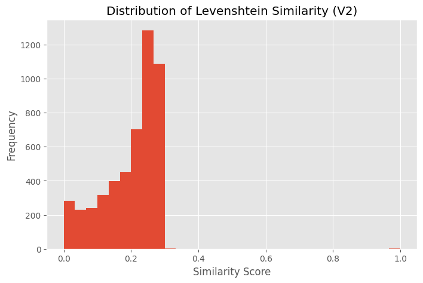

```python
df_sample["is_suspicious"] = df_sample["levenshtein_similarity"].apply(
    lambda x: 1 if x is not None and x > 0.85 else 0
)

df_sample[["cleaned_text", "levenshtein_similarity", "is_suspicious"]].head()
plt.figure(figsize=(8,5))
df_sample["levenshtein_similarity"].dropna().plot(kind='hist', bins=30)
plt.title("Distribution of Levenshtein Similarity (V2)")
plt.xlabel("Similarity Score")
plt.ylabel("Frequency")
plt.show()
```

**Train-Test Split:**

It display the shapes of entire dataset as well as training and testing subsets after spliting the datset into features (cleaned_text) and labels. This is followed by stratified 80/20 train-test-split

```python
# Take sample for faster training
df_model = df.sample(5000, random_state=42)

X = df_model['cleaned_text']
y = df_model['label']

print(X.shape, y.shape)
X_train, X_test, y_train, y_test = train_test_split(
    X, y,
    test_size=0.2,
    random_state=42,
    stratify=y
)

print("Train size:", X_train.shape)
print("Test size:", X_test.shape)
```

```
(5000,) (5000,)
Train size: (4000,)
Test size: (1000,)
```

**PHASE 6 — MODELING**

**MODEL 1 — Logistic Regression (TF-IDF)**

```python
from sklearn.feature_extraction.text import TfidfVectorizer
tfidf = TfidfVectorizer(
    max_features=10000,
    ngram_range=(1, 2),
    stop_words='english'
)
X_train_tfidf = tfidf.fit_transform(X_train)
X_test_tfidf  = tfidf.transform(X_test)
print("TF-IDF Train Shape:", X_train_tfidf.shape)
print("TF-IDF Test Shape:", X_test_tfidf.shape)
```

```
TF-IDF Train Shape: (4000, 10000)
TF-IDF Test Shape: (1000, 10000)
```

```python
from sklearn.linear_model import LogisticRegression
lr_model = LogisticRegression(
    max_iter=1000,
    class_weight='balanced',
    n_jobs=-1
)

lr_model.fit(X_train_tfidf, y_train)

print("Logistic Regression training completed")
```

```
Logistic Regression training completed
```

Here we calculated important performance measures while evaluating the logistic regression model on test set. The model performs well overall differentiating between fake and true news, acheving 91% accuracy with precision 0.894, recall 0.933 and F1 score of 0.913

```python
y_pred = lr_model.predict(X_test_tfidf)
y_prob = lr_model.predict_proba(X_test_tfidf)[:, 1]
accuracy  = accuracy_score(y_test, y_pred)
precision = precision_score(y_test, y_pred)
recall    = recall_score(y_test, y_pred)
f1        = f1_score(y_test, y_pred)
print("Accuracy :", round(accuracy, 4))
print("Precision:", round(precision, 4))
print("Recall   :", round(recall, 4))
print("F1-score :", round(f1, 4))
```

```
Accuracy : 0.91
Precision: 0.8939
Recall   : 0.9328
F1-score : 0.913
```

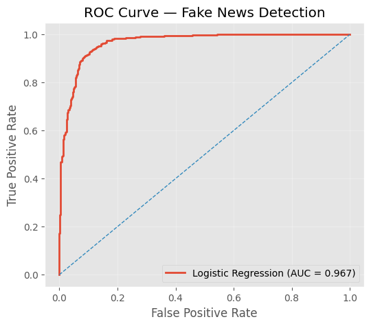

```python
from sklearn.metrics import roc_curve, roc_auc_score
auc_score = roc_auc_score(y_test, y_prob)

fpr, tpr, thresholds = roc_curve(y_test, y_prob)
plt.figure(figsize=(6, 5))

plt.plot(
    fpr, tpr,
    linewidth=2,
    label=f"Logistic Regression (AUC = {auc_score:.3f})"
)
plt.plot([0, 1], [0, 1], linestyle='--', linewidth=1)
plt.xlabel("False Positive Rate")
plt.ylabel("True Positive Rate")
plt.title("ROC Curve — Fake News Detection")
plt.legend(loc="lower right")
plt.grid(alpha=0.3)
plt.show()
```

**Confusion Matrix:**

This visualization shows provide a clear picture of classification perforamnce and misclassification by presenting a confusion matrix for the logistic regression model that displays the count of True vs Predicted labels for real and fake news.

```
[[438  56]
 [ 34 472]]
```

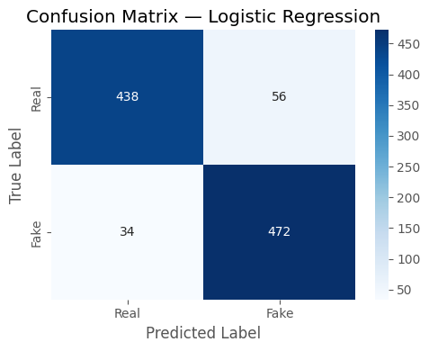

```python
from sklearn.metrics import confusion_matrix
cm = confusion_matrix(y_test, y_pred)
print(cm)
plt.figure(figsize=(5, 4))

sns.heatmap(
    cm,
    annot=True,
    fmt="d",
    cmap="Blues",
    xticklabels=["Real", "Fake"],
    yticklabels=["Real", "Fake"]
)

plt.xlabel("Predicted Label")
plt.ylabel("True Label")
plt.title("Confusion Matrix — Logistic Regression")
plt.tight_layout()
plt.show()
```

**Model 2 — LSTM (Long Short-Term Memory)**

```python
from tensorflow.keras.models import Sequential
from tensorflow.keras.layers import Embedding, LSTM, Dense, Dropout
MAX_WORDS = 20000   # Vocabulary size
MAX_LEN   = 300     # Sequence length
EMBED_DIM = 128     # Embedding dimension
```

**Build LSTM Model Architecture:**

An LSTM- based deep learning model for detecting fake news is defined and assembeled this code. In order to capture sequential dependencies in the text, and LSTM layer with 128 int comes after an embedding layer that transforms input token into dense vectors. A dense layer with ReLU activation offers intermidate feature transformation, adn droput layer are added for regulization and overfitting reduction. The final output layer predicts binary label (Real or Fake) using sigmoid activition. the model's architecture summary gives a sigmoid acivation. The model's architecture summary gives summary of all layers and parameter, and its compile using Adam optimizer with binary cross-entropy loss.

```python
model_lstm = Sequential(name="FakeNews_LSTM_Model")
model_lstm.add(
    Embedding(
        input_dim=MAX_WORDS,
        output_dim=EMBED_DIM,
        input_length=MAX_LEN,
        name="Embedding_Layer"
    )
)
model_lstm.add(
    LSTM(
        units=128,
        return_sequences=False,
        name="LSTM_Layer"
    )
)
model_lstm.add(Dropout(0.3, name="Dropout_1"))

model_lstm.add(
    Dense(
        64,
        activation='relu',
        name="Dense_Layer"
    )
)
model_lstm.add(Dropout(0.3, name="Dropout_2"))
model_lstm.add(
    Dense(
        1,
        activation='sigmoid',
        name="Output_Layer"
    )
)
model_lstm.build(input_shape=(None, MAX_LEN))
model_lstm.compile(
    optimizer='adam',
    loss='binary_crossentropy',
    metrics=['accuracy']
)
model_lstm.summary()
```

```
Model: "FakeNews_LSTM_Model"
```

```
┏━━━━━━━━━━━━━━━━━━━━━━━━━━━━━━━━━┳━━━━━━━━━━━━━━━━━━━━━━━━┳━━━━━━━━━━━━━━━┓
┃ Layer (type)                    ┃ Output Shape           ┃       Param # ┃
┡━━━━━━━━━━━━━━━━━━━━━━━━━━━━━━━━━╇━━━━━━━━━━━━━━━━━━━━━━━━╇━━━━━━━━━━━━━━━┩
│ Embedding_Layer (Embedding)     │ (None, 300, 128)       │     2,560,000 │
├─────────────────────────────────┼────────────────────────┼───────────────┤
│ LSTM_Layer (LSTM)               │ (None, 128)            │       131,584 │
├─────────────────────────────────┼────────────────────────┼───────────────┤
│ Dropout_1 (Dropout)             │ (None, 128)            │             0 │
├─────────────────────────────────┼────────────────────────┼───────────────┤
│ Dense_Layer (Dense)             │ (None, 64)             │         8,256 │
├─────────────────────────────────┼────────────────────────┼───────────────┤
│ Dropout_2 (Dropout)             │ (None, 64)             │             0 │
├─────────────────────────────────┼────────────────────────┼───────────────┤
│ Output_Layer (Dense)            │ (None, 1)              │            65 │
└─────────────────────────────────┴────────────────────────┴───────────────┘
```

```
 Total params: 2,699,905 (10.30 MB)
```

```
 Trainable params: 2,699,905 (10.30 MB)
```

```
 Non-trainable params: 0 (0.00 B)
```

```python
from tensorflow.keras.utils import plot_model
plot_model(
    model_lstm,
    to_file="lstm_model_lr.png",
    show_shapes=True,
    show_layer_names=True,
    rankdir="LR",   # Left-to-Right
    dpi=200
)
```

[figure not shown]

**LSTM Training Callbacks:**

```python
from tensorflow.keras.callbacks import EarlyStopping, ModelCheckpoint

early_stop = EarlyStopping(
    monitor='val_loss',
    patience=2,
    restore_best_weights=True
)

checkpoint = ModelCheckpoint(
    filepath='lstm_best_model.keras',
    monitor='val_loss',
    save_best_only=True
)
```

The LSTM model is trained on the prepared sequences using validation, early halting and checkpointing after tokenizing and padding the text data for LSTM input.

```python
from tensorflow.keras.preprocessing.text import Tokenizer
from tensorflow.keras.preprocessing.sequence import pad_sequences

# Tokenize and pad X_train and X_test
tokenizer = Tokenizer(num_words=MAX_WORDS, oov_token="<unk>")
tokenizer.fit_on_texts(X_train)

X_train_sequences = tokenizer.texts_to_sequences(X_train)
X_test_sequences  = tokenizer.texts_to_sequences(X_test)

X_train_pad = pad_sequences(X_train_sequences, maxlen=MAX_LEN, padding='post', truncating='post')
X_test_pad  = pad_sequences(X_test_sequences,  maxlen=MAX_LEN, padding='post', truncating='post')

# Print shapes to verify
print("X_train_pad shape:", X_train_pad.shape)
print("X_test_pad shape:", X_test_pad.shape)

EPOCHS = 10
BATCH_SIZE = 64
history = model_lstm.fit(
    X_train_pad,
    y_train,
    validation_split=0.1,
    epochs=EPOCHS,
    batch_size=BATCH_SIZE,
    callbacks=[early_stop, checkpoint],
    verbose=1
)
```

```
X_train_pad shape: (4000, 300)
X_test_pad shape: (1000, 300)
57/57 ━━━━━━━━━━━━━━━━━━━━ 8s 30ms/step - accuracy: 0.5195 - loss: 0.6936 - val_accuracy: 0.4650 - val_loss: 0.6957
57/57 ━━━━━━━━━━━━━━━━━━━━ 1s 21ms/step - accuracy: 0.5629 - loss: 0.6767 - val_accuracy: 0.7300 - val_loss: 0.5853
57/57 ━━━━━━━━━━━━━━━━━━━━ 1s 26ms/step - accuracy: 0.7086 - loss: 0.5700 - val_accuracy: 0.6925 - val_loss: 0.5567
57/57 ━━━━━━━━━━━━━━━━━━━━ 2s 26ms/step - accuracy: 0.7325 - loss: 0.5355 - val_accuracy: 0.6925 - val_loss: 0.5528
57/57 ━━━━━━━━━━━━━━━━━━━━ 1s 23ms/step - accuracy: 0.7432 - loss: 0.5212 - val_accuracy: 0.7150 - val_loss: 0.5164
57/57 ━━━━━━━━━━━━━━━━━━━━ 1s 20ms/step - accuracy: 0.8090 - loss: 0.4635 - val_accuracy: 0.7250 - val_loss: 0.5328
57/57 ━━━━━━━━━━━━━━━━━━━━ 1s 18ms/step - accuracy: 0.8128 - loss: 0.4552 - val_accuracy: 0.7500 - val_loss: 0.6192
```

Transformers predicted probabilities into binary labels while evaluating the LSTM model on the test set. According to the classification report, mode's overall accuracy is 77% it is better. at recognizing false news than actual news with greater recall for fake news 0.93 and loewer reacll for fake news 0.93 nand lower recall for true news (0.62)

```python
# Predicted probabilities
y_prob = model_lstm.predict(X_test_pad).ravel()

# Convert probabilities to class labels
y_pred = (y_prob >= 0.5).astype(int)
from sklearn.metrics import classification_report

print(classification_report(
    y_test,
    y_pred,
    target_names=["Real News", "Fake News"]
))
from sklearn.metrics import accuracy_score

accuracy = accuracy_score(y_test, y_pred)
```

```
32/32 ━━━━━━━━━━━━━━━━━━━━ 1s 12ms/step
              precision    recall  f1-score   support

   Real News       0.89      0.62      0.73       494
   Fake News       0.71      0.93      0.81       506

    accuracy                           0.77      1000
   macro avg       0.80      0.77      0.77      1000
weighted avg       0.80      0.77      0.77      1000
```

**Confusion matrix**

It provide visual assessment of classification performances and misclassification by plotting a confusion matrix for the LSTM model, displaying true vs predicted labels for real and bogus news.

```
32/32 ━━━━━━━━━━━━━━━━━━━━ 0s 9ms/step
[[305 189]
 [ 37 469]]
```

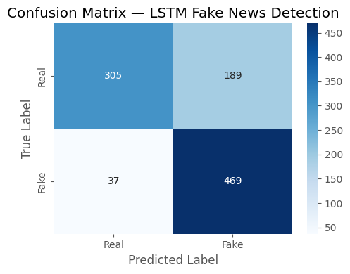

```python
y_prob = model_lstm.predict(X_test_pad).ravel()
y_pred = (y_prob >= 0.5).astype(int)
cm = confusion_matrix(y_test, y_pred)
print(cm)
plt.figure(figsize=(5,4))
sns.heatmap(
    cm,
    annot=True,
    fmt='d',
    cmap='Blues',
    xticklabels=['Real', 'Fake'],
    yticklabels=['Real', 'Fake']
)
plt.xlabel("Predicted Label")
plt.ylabel("True Label")
plt.title("Confusion Matrix — LSTM Fake News Detection")
plt.tight_layout()
plt.show()
```

**Model 3:- Transformer BERT (Hugging Face)**

```python
import torch
from transformers import (
    BertTokenizer,
    BertForSequenceClassification,
    Trainer,
    TrainingArguments
)
# Use sample for faster fine-tuning
df_bert = df.sample(4000, random_state=42)
texts = df_bert['cleaned_text'].astype(str).tolist()
labels = df_bert['label'].tolist()
X_train, X_test, y_train, y_test = train_test_split(
    texts, labels,
    test_size=0.2,
    stratify=labels,
    random_state=42
)
# Load BERT Tokenizer
tokenizer = BertTokenizer.from_pretrained("bert-base-uncased")
```

**Tokenization (BERT-style)**

```python
def tokenize_data(texts):
    return tokenizer(
        texts,
        padding=True,
        truncation=True,
        max_length=256,
        return_tensors="pt"
    )

train_encodings = tokenize_data(X_train)
test_encodings  = tokenize_data(X_test)
```

**Create Torch Dataset**

```python
class FakeNewsDataset(torch.utils.data.Dataset):
    def __init__(self, encodings, labels):
        self.encodings = encodings
        self.labels = labels

    def __getitem__(self, idx):
        item = {key: val[idx] for key, val in self.encodings.items()}
        item["labels"] = torch.tensor(self.labels[idx])
        return item

    def __len__(self):
        return len(self.labels)

train_dataset = FakeNewsDataset(train_encodings, y_train)
test_dataset  = FakeNewsDataset(test_encodings, y_test)
```

**Load BERT with Classification Head, HuggingFace automatically adds a classification head on top of BERT.**

```python
model_bert = BertForSequenceClassification.from_pretrained(
    "bert-base-uncased",
    num_labels=2
)
```

```
Some weights of BertForSequenceClassification were not initialized from the model checkpoint at bert-base-uncased and are newly initialized: ['classifier.bias', 'classifier.weight']
You should probably TRAIN this model on a down-stream task to be able to use it for predictions and inference.
```

```python
!pip install -U transformers accelerate
```

**BERT Model Summary:**

Provides a succinct overview of the model architecture by generating a summary of the BERT model's layers, including each layer's name, paramater shape, total number of parameters, and trainability.

```python
def bert_model_summary(model):
    rows = []
    for name, param in model.named_parameters():
        rows.append([
            name,
            tuple(param.shape),
            param.numel(),
            param.requires_grad
        ])
    return pd.DataFrame(
        rows,
        columns=["Layer Name", "Shape", "Param Count", "Trainable"]
    )

bert_summary_df = bert_model_summary(model_bert)
bert_summary_df.head(10)
```

|  | Layer Name | Shape | Param Count | Trainable |
| --- | --- | --- | --- | --- |
| 0 | bert.embeddings.word_embeddings.weight | (30522, 768) | 23440896 | True |
| 1 | bert.embeddings.position_embeddings.weight | (512, 768) | 393216 | True |
| 2 | bert.embeddings.token_type_embeddings.weight | (2, 768) | 1536 | True |
| 3 | bert.embeddings.LayerNorm.weight | (768,) | 768 | True |
| 4 | bert.embeddings.LayerNorm.bias | (768,) | 768 | True |
| 5 | bert.encoder.layer.0.attention.self.query.weight | (768, 768) | 589824 | True |
| 6 | bert.encoder.layer.0.attention.self.query.bias | (768,) | 768 | True |
| 7 | bert.encoder.layer.0.attention.self.key.weight | (768, 768) | 589824 | True |
| 8 | bert.encoder.layer.0.attention.self.key.bias | (768,) | 768 | True |
| 9 | bert.encoder.layer.0.attention.self.value.weight | (768, 768) | 589824 | True |

**Training Arguments (Fine-Tuning):**

```python
training_args = TrainingArguments(
    output_dir='./results',
    num_train_epochs=2,
    per_device_train_batch_size=32,
    per_device_eval_batch_size=32,
    warmup_steps=200,
    weight_decay=0.01,
    logging_dir='./logs',
    logging_steps=200,
    eval_strategy="epoch",
    save_strategy="epoch",
    load_best_model_at_end=True,
    metric_for_best_model="f1",
    report_to="none"
)
```

```python
def compute_metrics(pred):
    labels = pred.label_ids
    preds = np.argmax(pred.predictions, axis=1)

    precision, recall, f1, _ = precision_recall_fscore_support(
        labels, preds, average="binary"
    )
    acc = accuracy_score(labels, preds)

    return {
        "accuracy": acc,
        "precision": precision,
        "recall": recall,
        "f1": f1
    }
trainer = Trainer(
    model=model_bert,
    args=training_args,
    train_dataset=train_dataset,
    eval_dataset=test_dataset,
    compute_metrics=compute_metrics
)
```

**Fine-Tune BERT, Evaluation of BERT**